# Walmart Case Study

# Data Science Case Study: Demand Forecasting

This document provides a simple case study on predicting Walmart sales across different cities and product categories.

## Exploratory Data Analysis

We start by exploring the data to better understand its structure, identify any inconsistencies, and uncover key patterns or trends that could help guide our approach.

#### Data Handling

```r
require(tidyverse)
require(purrr)
require(reshape2)

# ----------------------------------------------------------------------------- #
`%+%` = paste0

# ----------------------------------------------------------------------------- #
MAIN_FOLDER = 'C:/Users/usr/projects/consultorias/job_tests/Shipbob-Kopius/DS-CaseStudy-SalesForecast/data/m5/datasets/'

# ----------------------------------------------------------------------------- #

da = read_csv(MAIN_FOLDER %+% 'calendar.csv')

sales_train_validation = read_csv(MAIN_FOLDER %+% 'sales_train_validation.csv')
sales_test_validation = read_csv(MAIN_FOLDER %+% 'sales_test_validation.csv')
sales_test_evaluation = read_csv(MAIN_FOLDER %+% 'sales_test_evaluation.csv')


# -------------------------------------- #
# -- Add day index to calendar dates
# -------------------------------------- #
da['day_index'] = paste0('d_', 1:nrow(da))


# -------------------------------------- #
# -- sales wide to long
# -------------------------------------- #
sales_train_validation_long = melt(
  sales_train_validation
  , id.vars=c("item_id", "dept_id", "cat_id", "store_id", "state_id")
  , variable.name="day_index"
  , value.name="sales"
)

sales_test_validation_long = melt(
  sales_test_validation
  , id.vars=c("item_id", "dept_id", "cat_id", "store_id", "state_id")
  , variable.name="day_index"
  , value.name="sales"
)

sales_test_evaluation_long = melt(
  sales_test_evaluation
  , id.vars=c("item_id", "dept_id", "cat_id", "store_id", "state_id")
  , variable.name="day_index"
  , value.name="sales"
)

# -------------------------------------- #
# -- add split description
# -------------------------------------- #

sales_train_validation_long = sales_train_validation_long %>%
  mutate(split = 'train')

sales_test_validation_long = sales_test_validation_long %>%
  mutate(split = 'val')

sales_test_evaluation_long = sales_test_evaluation_long %>%
  mutate(split = 'test')


sales_da = bind_rows(
  sales_train_validation_long
  , sales_test_validation_long
  , sales_test_evaluation_long
)

# -------------------------------------- #
# -- Join callendar dates
# -------------------------------------- #

demand_da = left_join(
  sales_da
  , da
  , by='day_index'
)

demand_da = demand_da %>% as.tibble()
```

### Number of Unique states, departaments and categories

```r
unique_state_id = demand_da$state_id %>% unique() %>% length()
unique_dept_id = demand_da$dept_id %>% unique() %>% length()
unique_cat_id = demand_da$cat_id %>% unique() %>% length()

cat(
  paste('unique state_id: ', unique_state_id)
, paste('\nunique dept_id: ', unique_dept_id)
, paste('\nunique cat_id: ', unique_cat_id)
)
```

```
## unique state_id:  3
## unique dept_id:  7
## unique cat_id:  3
```

#### Check Date Ranges.

```r
# -- Date range of items -- #
date_rage_items = demand_da %>%
  group_by(
    store_id
    , item_id
  ) %>%
  summarise(
    min_date = min(date)
    , max_date = max(date)

  )

date_rage_items$min_date %>% unique()
```

```
## [1] "2011-01-29"
```

```r
date_rage_items$max_date %>% unique()
```

```
## [1] "2016-06-19"
```

```r
## all items have the same date rage across all stores
```

#### Number of events per state –

All stores have the same number of events

```r
demand_da$event_name_1 %>% unique()
```

```
##  [1] NA                    "SuperBowl"           "ValentinesDay"
##  [4] "PresidentsDay"       "LentStart"           "LentWeek2"
##  [7] "StPatricksDay"       "Purim End"           "OrthodoxEaster"
## [10] "Pesach End"          "Cinco De Mayo"       "Mother's day"
## [13] "MemorialDay"         "NBAFinalsStart"      "NBAFinalsEnd"
## [16] "Father's day"        "IndependenceDay"     "Ramadan starts"
## [19] "Eid al-Fitr"         "LaborDay"            "ColumbusDay"
## [22] "Halloween"           "EidAlAdha"           "VeteransDay"
## [25] "Thanksgiving"        "Christmas"           "Chanukah End"
## [28] "NewYear"             "OrthodoxChristmas"   "MartinLutherKingDay"
## [31] "Easter"
```

```r
events_by_store = demand_da %>%
  group_by(
    store_id
  ) %>%
  summarise(events = n_distinct(event_name_1))
events_by_store
```

| store_id | events |
| --- | --- |
| CA_1 | 31 |
| CA_2 | 31 |
| CA_3 | 31 |
| CA_4 | 31 |
| TX_1 | 31 |
| TX_2 | 31 |
| TX_3 | 31 |
| WI_1 | 31 |
| WI_2 | 31 |
| WI_3 | 31 |

### Items per category and state

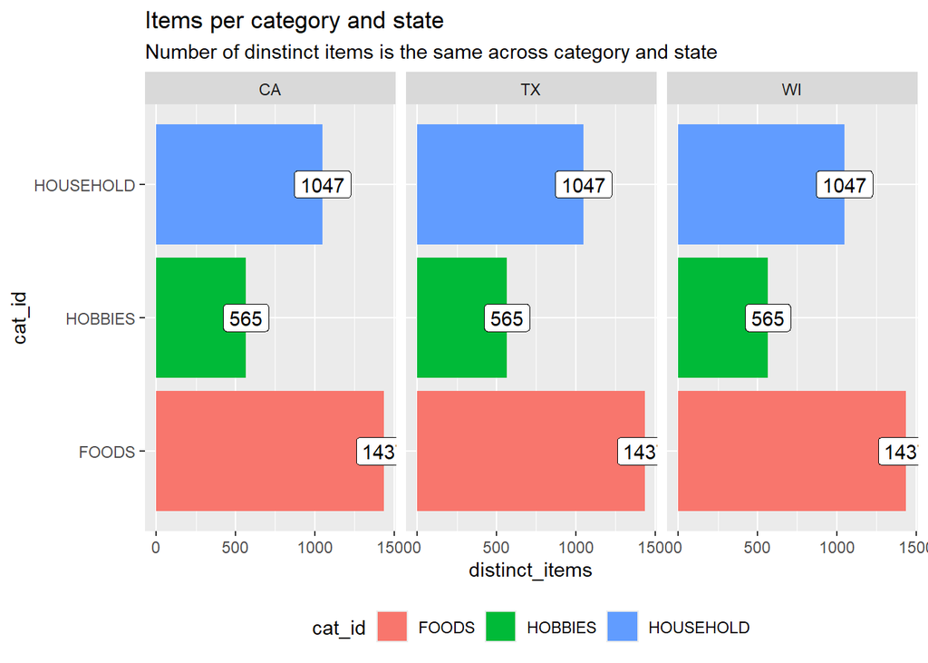

```r
items_dep_da = demand_da %>%
  group_by(
    state_id
    , cat_id
    # , dept_id
  ) %>%
  summarise(distinct_items = n_distinct(item_id))


items_dep_da %>%
  ggplot(aes(
    x = cat_id
    , y = distinct_items
  )) +
  geom_bar(aes(fill = cat_id), stat = 'identity') +
  geom_label(aes(label=distinct_items))+
  facet_wrap(~state_id) +
  labs(
    title = 'Items per category and state'
    , subtitle = 'Number of dinstinct items is the same across category and state'
  ) +
  coord_flip()+
  theme(legend.position = 'bottom')
```

#### Alaysis of distribution

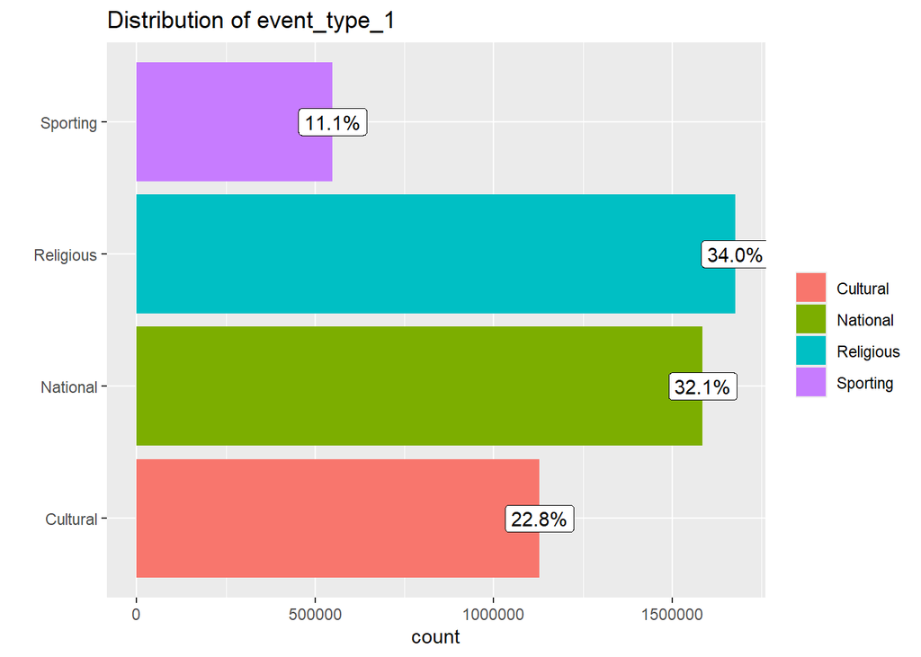

```r
make_barplot = function(
  aux_da
  , y_col
){
  # aux_da = demand_da
  # y_col = 'event_type_1'

  aux_da['y_col'] = aux_da[y_col]

  # -- remove NA
  aux_da = aux_da[!is.na(aux_da[['y_col']]), ]


  grouped_da = aux_da %>%
    group_by(
      y_col
    ) %>%
    summarise(count = n()) %>%
    mutate(perc = scales::percent(count / sum(count)))


  gg_aux = grouped_da %>%
    ggplot(aes(
      x = y_col
      , y = count
    )) +
    geom_bar(aes(fill = y_col), stat = 'identity') +
    #geom_label(aes(label=paste0(count, '\n', perc)))+
    geom_label(aes(label=perc))+
    labs(
      title = paste0('Distribution of ', y_col)
      , fill = ''
      , x = ''
    )+
    coord_flip()

  return(gg_aux)

}

make_barplot(demand_da, 'event_type_1')
```

Most event_type_1 occurrences are either Religious or National, with both having nearly the same number of events. Cultural events occur less frequently, while Sporting events have the fewest, with about one-third the occurrences of the main categories.

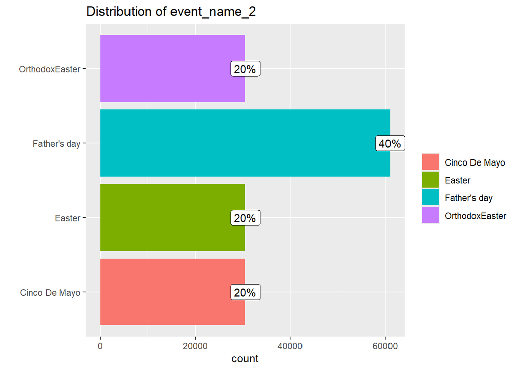

```r
make_barplot(demand_da, 'event_name_2')
```

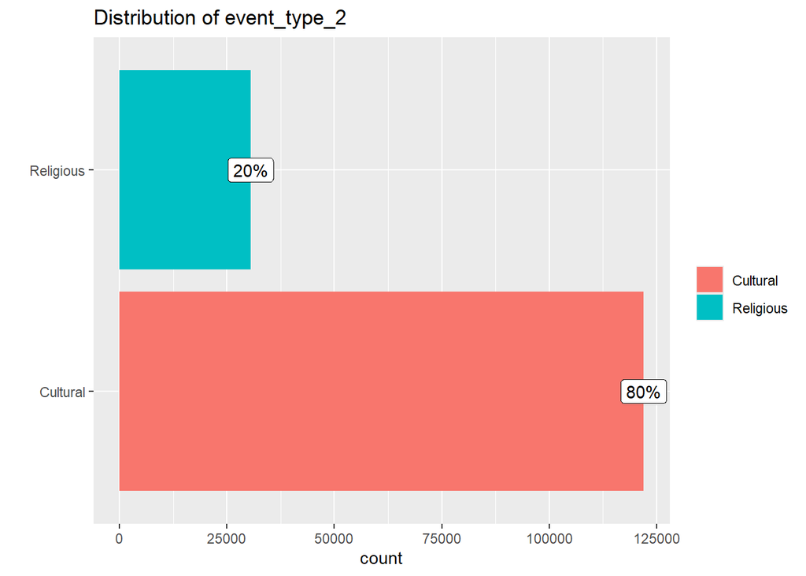

```r
make_barplot(demand_da, 'event_type_2')
```

The vast majority of event_type_2 are Cultural.

#### cat_id

the category FOODS is the one that sell the most, followed by HOUSEHOLD and HOBBIES

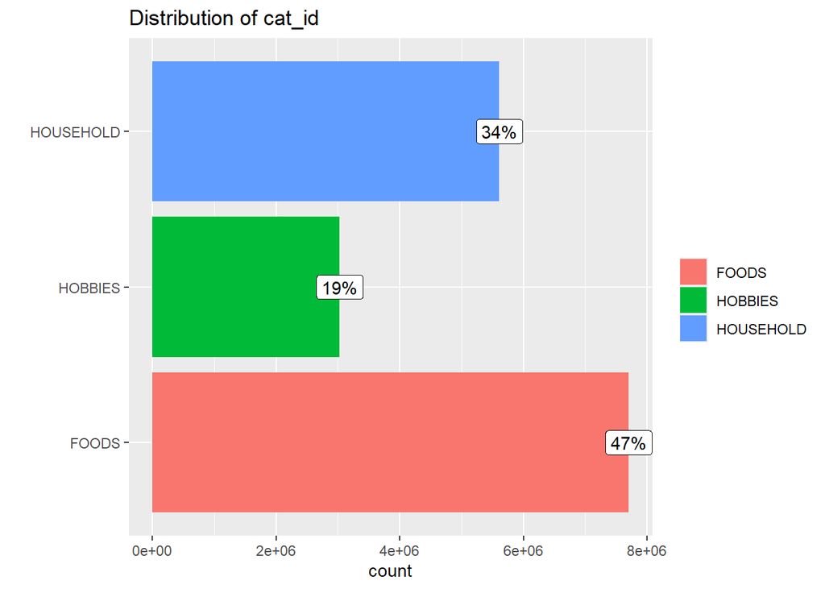

```r
make_barplot(
  demand_da %>%
    filter(date >='2015-01-01')
  , 'cat_id')
```

#### dept_id

The FOODS_3 dept_id accounts for the largest number of observations. HOBBIES_1 has approximately three times the observations of HOBBIES_2, while HOUSEHOLD_1 and HOUSEHOLD_2 have nearly identical numbers of observations.

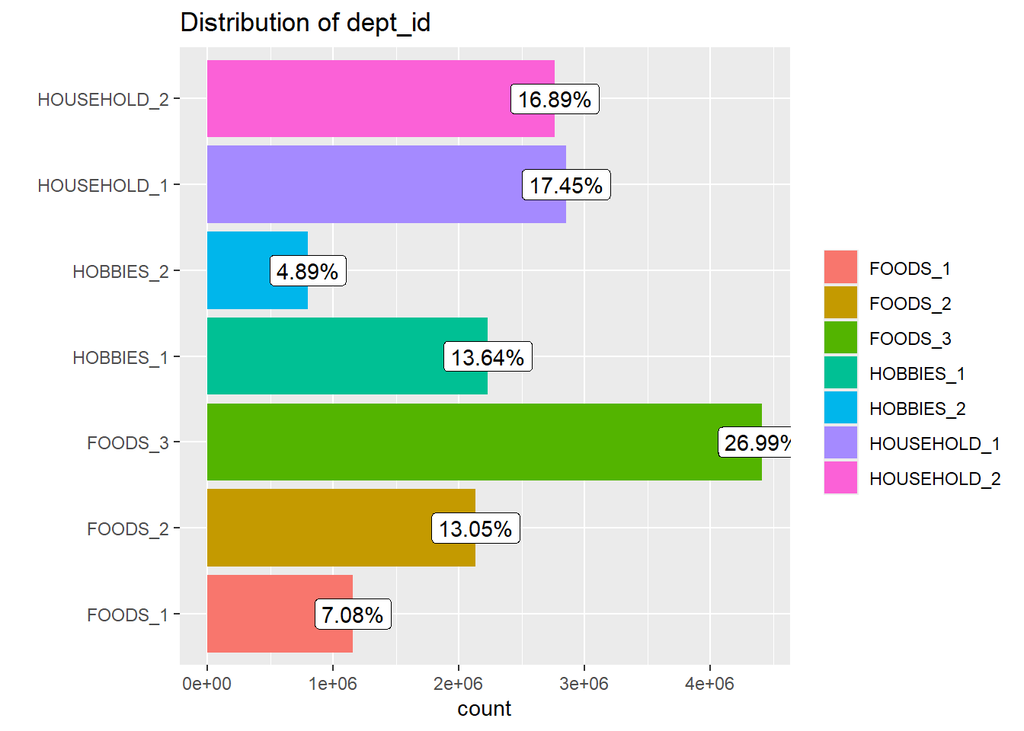

```r
make_barplot(
  demand_da %>%
    filter(date >='2015-01-01')
  , 'dept_id')
```

#### state_id

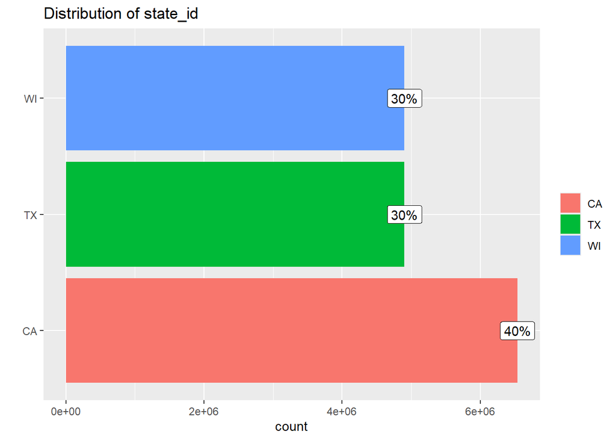

```r
make_barplot(
  demand_da %>%
    filter(date >='2015-01-01')
  , 'state_id')
```

### Glance at some time series

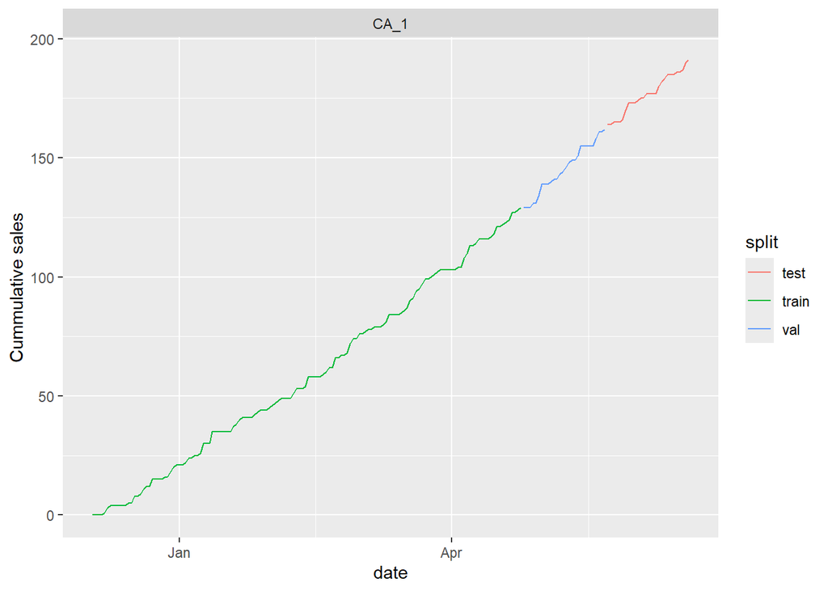

```r
# -- glance at some time series
store_ids = unique(demand_da$store_id)

aux_da = demand_da %>%
  filter(item_id == demand_da$item_id[[1]]) %>%
  # filter(store_id %in% store_ids[1:3])
  filter(store_id == demand_da$store_id[1])


aux_da %>%
  tail(200) %>%
  ggplot(aes(
    x = date
    , y = cumsum(sales)
    , col = split
  )) +
  geom_line() +
  labs(y='Cummulative sales')+
  facet_wrap(~store_id, ncol=1)
```

# Save a sample

```r
# ------------------------------------------------------------ #
# -- Save a sample
# ------------------------------------------------------------ #


unique_items = unique(demand_da$item_id)
unique_stores = unique(demand_da$store_id)

sample_items = sample(unique_items, 10)
samples_stores = sample(unique_stores, 10)


sample_df = demand_da %>%
  filter(
    (item_id %in% sample_items) &
    (store_id %in% samples_stores)
    )

dim(sample_df)
```

```
## [1] 196900     21
```

```r
write.csv(sample_df, paste0(MAIN_FOLDER, 'sample_demand_da.csv'))
```